# MUSA 508 Midterm: Zillow Housing Algorithm Assignment - REVISED

Myron Bañez and Amelia Marcantonio-Fields

11/29/2021

# Introduction:

This project sets out to recreate a home sale price prediction algorithm. The project is loosely based around Zillow’s Zestimate function, and explores potential features that might explain sale prices in Boulder County, CO, USA. Sale prediction algorithms can be important for evaluating what features might affect home price and further might give the ability for people to make more informed decisions about long-term investments. It also may undercover inequities in the housing market that could be addressed.

This is an incredibly difficult exercise in both the content (using regressions and Machine Learning to build the models), but also in the data wrangling. While great data is available, it can be hard to quantify features that impact home prices and attribute aspects like “neighborhood-feel” to homes. Further, many variables included may be colinear, meaning that they might relate to one another and then pose challenges on the effectiveness of the model.

We set our research design using the hedonic model, a framework in which home prices are predicted utilizing a variety of variables such as internal characteristics related to the home and external or spatial features such as neighborhood demographics, libraries, open space, and more. Our overall modeling strategy was to gather variables that might have an affect on the housing market, clean them, and test them as regressions (to see how meaningful they might be). Once we got a regression model that was moderately meaningful, we continued the process to evaluate it. In determining our model’s predictive power, we must pay close attention towards many statistical metrics such as the mean absolute percentage errors, Moran’s I, and adjusted R-squared.

In the end, we produce an adequate model with some weaknesses. Unfortunately, our model does produce a relatively high percentage of error–this may be because it generally underpredicts and struggles to predict incredibly expensives houses. Despite the accuracy, our model is pretty generalizable across block groups and demographics in Boulder, Colorado. However, beyond Colorado, our model may not be up for the challenge of predicting home prices. More on this throughout the deliverable.

Overall, there are many learning opportunities and key takeaways from our research that will be able to inform and guide future data scientists and the housing industry towards accurate home pricing. Below is the code and more information on how our model performs.

# Set Up

## Boulder Home Price Data

Below is code to import the working dataset that our model will be based off of. The dataset includes home price sales and characteristics from 2019-2021 in Boulder, CO. The model we will build predicts price and uses some of the internal characteristics from this dataset to inform those predictions.

```r
BoulderHousingData <-
  st_read("studentData.geojson", crs = "ESRI:102254") %>%
  st_transform('ESRI:102653')
## Reading layer `studentData' from data source
##   `C:\Users\ammar\OneDrive\Desktop\CPLN592\Midterm\MUSA_508_Midterm\studentData.geojson'
##   using driver `GeoJSON'
## Simple feature collection with 11364 features and 48 fields
## Geometry type: POINT
## Dimension:     XY
## Bounding box:  xmin: 907857.2 ymin: 535711.1 xmax: 952487.4 ymax: 574366.8
## Projected CRS: NAD_1983_HARN_StatePlane_Colorado_Central_FIPS_0502

Boulder.Boundary <-
  st_read("https://opendata.arcgis.com/datasets/964b8f3b3dbe401bb28d49ac93d29dc4_0.geojson") %>%
  st_transform(st_crs(BoulderHousingData))
## Reading layer `County_Boundary' from data source
##   `https://opendata.arcgis.com/datasets/964b8f3b3dbe401bb28d49ac93d29dc4_0.geojson'
##   using driver `GeoJSON'
## Simple feature collection with 1 feature and 3 fields
## Geometry type: MULTIPOLYGON
## Dimension:     XY
## Bounding box:  xmin: -105.6945 ymin: 39.91297 xmax: -105.0528 ymax: 40.26396
## Geodetic CRS:  WGS 84
```

## Cleaning Internal Variables

For the rest of the code, we will refer to “internal variables” as variables embedded in the Boulder Home Price Data above, or Boulder Housing Data. As explained above, internal characteristics are one factor in the hedonic model to predict home prices. This chunk of code cleans a few of the variables we will include in our model later on, like total baths.

```r
#Adding a price/sq foot variable and total baths variable

BoulderHousingData <-
  BoulderHousingData %>%
  mutate(pricesqft = ifelse(TotalFinishedSF > 0, (price/TotalFinishedSF), 0),
        totalbaths = (nbrHalfBaths *0.5)+(nbrThreeQtrBaths)+(nbrFullBaths*1))
```

## Adding Data: Amenities/Public Services

In order to start building a model off of potential features that relate to the housing market, we must import some external variables! Another aspect of the hedonic model is distance from certain amenities–this is what these variables will mostly over. The code below pulls in data that is categorized as either an amenity or public service and we pulled: library locations, trail head locations, open space, marijuana establishments, lakes and reservoir locations, as well as public and private schools. The data below is sourced from: https://www.bouldercounty.org/government/open-data/ and https://www.cde.state.co.us/schoolview

```r
BoulderLibraries <-
   st_read("https://opendata.arcgis.com/datasets/7f4ea25ba87345e380d2e896611d2588_0.geojson") %>%
  st_transform(st_crs(BoulderHousingData))
## Reading layer `Libraries' from data source
##   `https://opendata.arcgis.com/datasets/7f4ea25ba87345e380d2e896611d2588_0.geojson'
##   using driver `GeoJSON'
## Simple feature collection with 19 features and 7 fields
## Geometry type: POINT
## Dimension:     XY
## Bounding box:  xmin: -105.5099 ymin: 39.96059 xmax: -105.0989 ymax: 40.22287
## Geodetic CRS:  WGS 84

BoulderTrailHeads <-
   st_read("https://opendata.arcgis.com/datasets/3a950053bbef46c6a3c2abe3aceee3de_0.geojson") %>%
  st_transform(st_crs(BoulderHousingData))
## Reading layer `Boulder_Area_Trailheads' from data source
##   `https://opendata.arcgis.com/datasets/3a950053bbef46c6a3c2abe3aceee3de_0.geojson'
##   using driver `GeoJSON'
## Simple feature collection with 331 features and 9 fields
## Geometry type: POINT
## Dimension:     XY
## Bounding box:  xmin: -105.8584 ymin: 39.91423 xmax: -105.009 ymax: 40.44153
## Geodetic CRS:  WGS 84

BoulderOpenSpace <-
   st_read("https://opendata.arcgis.com/datasets/61728921abcb481fa98b9b07cfd7c95d_0.geojson") %>%
  st_transform(st_crs(BoulderHousingData))
## Reading layer `County_Open_Space' from data source
##   `https://opendata.arcgis.com/datasets/61728921abcb481fa98b9b07cfd7c95d_0.geojson'
##   using driver `GeoJSON'
## Simple feature collection with 2057 features and 24 fields
## Geometry type: MULTIPOLYGON
## Dimension:     XY
## Bounding box:  xmin: -105.6661 ymin: 39.89269 xmax: -105.017 ymax: 40.26848
## Geodetic CRS:  WGS 84

BoulderMarijuanaEstablishments <-
   st_read("https://opendata.arcgis.com/datasets/425a0adb547a4faba4b741a4fe4373b1_0.geojson") %>%
  st_transform(st_crs(BoulderHousingData))
## Reading layer `Marijuana_Establishments' from data source
##   `https://opendata.arcgis.com/datasets/425a0adb547a4faba4b741a4fe4373b1_0.geojson'
##   using driver `GeoJSON'
## Simple feature collection with 33 features and 28 fields
## Geometry type: POINT
## Dimension:     XY
## Bounding box:  xmin: -105.286 ymin: 40.00162 xmax: -105.1021 ymax: 40.21266
## Geodetic CRS:  WGS 84

BoulderLakesandReservoirs <-
   st_read("https://opendata.arcgis.com/datasets/e0759cd6dc8f4990a04b77a29c988b55_0.geojson") %>%
   st_transform(st_crs(BoulderHousingData))
## Reading layer `Lakes_and_Reservoirs' from data source
##   `https://opendata.arcgis.com/datasets/e0759cd6dc8f4990a04b77a29c988b55_0.geojson'
##   using driver `GeoJSON'
## Simple feature collection with 2043 features and 27 fields
## Geometry type: MULTIPOLYGON
## Dimension:     XY
## Bounding box:  xmin: -105.6983 ymin: 39.852 xmax: -104.9438 ymax: 40.34869
## Geodetic CRS:  WGS 84

BoulderSchools <-
  st_read("BoulderSchools_Geocode_Proj.shp", crs = "ESRI:102653")
## Reading layer `BoulderSchools_Geocode_Proj' from data source
##   `C:\Users\ammar\OneDrive\Desktop\CPLN592\Midterm\MUSA_508_Midterm\BoulderSchools_Geocode_Proj.shp'
##   using driver `ESRI Shapefile'
## Simple feature collection with 207 features and 84 fields
## Geometry type: POINT
## Dimension:     XY
## Bounding box:  xmin: 2992787 ymin: 1212206 xmax: 7752053 ymax: 2501119
## Projected CRS: NAD_1983_StatePlane_Colorado_North_FIPS_0501_Feet

BoulderPublicSchools <- subset(BoulderSchools, BoulderSchools$USER_Publi == 1)
BoulderPrivateSchools <- subset(BoulderSchools, BoulderSchools$USER_Publi == 0)
```

## Adding Data: Spatial Structure

We also included variables that relate to the demographic and environmental makeup of Boulder, CO to try to explain neighborhood or spatial affects beyond just XY points of amenities on a map. The variables pulled for this analysis were census data about race and income, and designated environmental hazards or special views. Variables below are from: https://www.socialexplorer.com/home and https://www.bouldercounty.org/government/open-data/

```r
#race, median household income, education levels
BoulderCensusData <-
  st_read("BoulderCO_Proj.shp", crs = "ESRI:102653")
## Reading layer `BoulderCO_Proj' from data source
##   `C:\Users\ammar\OneDrive\Desktop\CPLN592\Midterm\MUSA_508_Midterm\BoulderCO_Proj.shp'
##   using driver `ESRI Shapefile'
## Simple feature collection with 200 features and 25 fields
## Geometry type: MULTIPOLYGON
## Dimension:     XY
## Bounding box:  xmin: 2945512 ymin: 1211128 xmax: 3125345 ymax: 1338641
## Projected CRS: NAD_1983_StatePlane_Colorado_North_FIPS_0501_Feet

BoulderCensusData <-
  BoulderCensusData %>%
  mutate(BG = GEOID)

BoulderScenicCorridor <-
   st_read("https://opendata.arcgis.com/datasets/749ed0a11e454f64a0e5f7c51a786129_0.geojson") %>%
   st_transform(st_crs(BoulderHousingData))
## Reading layer `Peak_To_Peak_Scenic_Corridor' from data source
##   `https://opendata.arcgis.com/datasets/749ed0a11e454f64a0e5f7c51a786129_0.geojson'
##   using driver `GeoJSON'
## Simple feature collection with 1593 features and 6 fields
## Geometry type: MULTIPOLYGON
## Dimension:     XY
## Bounding box:  xmin: -105.5472 ymin: 39.93224 xmax: -105.4367 ymax: 40.26143
## Geodetic CRS:  WGS 84

BoulderGeologicalHazards <-
   st_read("Geological_Hazards.geojson") %>%
   st_transform(st_crs(BoulderHousingData))
## Reading layer `Geological_Hazards' from data source
##   `C:\Users\ammar\OneDrive\Desktop\CPLN592\Midterm\MUSA_508_Midterm\Geological_Hazards.geojson'
##   using driver `GeoJSON'
## Simple feature collection with 303 features and 9 fields
## Geometry type: POLYGON
## Dimension:     XY
## Bounding box:  xmin: -105.6945 ymin: 39.91318 xmax: -105.0528 ymax: 40.26396
## Geodetic CRS:  WGS 84

BoulderFloodZones <-
   st_read("https://opendata.arcgis.com/datasets/a9624bd25d854ef7ab0d543e9490ce48_0.geojson") %>%
   st_transform(st_crs(BoulderHousingData))
## Reading layer `Flood_2013_Inundated_Areas' from data source
##   `https://opendata.arcgis.com/datasets/a9624bd25d854ef7ab0d543e9490ce48_0.geojson'
##   using driver `GeoJSON'
## Simple feature collection with 165 features and 6 fields
## Geometry type: MULTIPOLYGON
## Dimension:     XY
## Bounding box:  xmin: -105.4942 ymin: 39.91283 xmax: -105.0547 ymax: 40.26225
## Geodetic CRS:  WGS 84

BoulderWildfireHistory <-
   st_read("https://opendata.arcgis.com/datasets/61f20f4a64274969a9e740eda5c62de7_0.geojson") %>%
   st_transform(st_crs(BoulderHousingData))
## Reading layer `Wildfire_History' from data source
##   `https://opendata.arcgis.com/datasets/61f20f4a64274969a9e740eda5c62de7_0.geojson'
##   using driver `GeoJSON'
## Simple feature collection with 42 features and 7 fields
## Geometry type: MULTIPOLYGON
## Dimension:     XY
## Bounding box:  xmin: -105.5855 ymin: 39.91812 xmax: -105.2345 ymax: 40.23306
## Geodetic CRS:  WGS 84
```

## Adding External Variables to the Big Dataset

To start conducting analysis, we must reconfigure certain variables and attribute them to specific home sales. The code below goes through this process. We used three different types of methodology to measure both distance and occurrences, which were 1. fixed-buffer analysis (set counts in a half mile radius), 2. k-nearest neighborhood (distance to a number of institutions), and 3. spatial join of both descriptive and binary attributes. In sum, we introduced variables that related to open space, lakes and reservoirs, libraries, trailheads, schools, marijuana establishments, scenery, flood zones, wildfires, census data, and geological hazards to see if they would be meaningful to the predictions.

```r
# Fixed Buffer Distance: Open Space & Lakes + Reservoirs

BoulderOpenSpaceGeo <- BoulderOpenSpace %>%
  dplyr::select(geometry)
BoulderLakesandReservoirsGeo <- BoulderLakesandReservoirs %>%
  dplyr:: select(geometry)

BoulderHousingData.Buffer.OpenSpace =
  BoulderHousingData %>%
    st_buffer(2640) %>%
    stats::aggregate(mutate(BoulderLakesandReservoirsGeo, counter = 1),., sum) %>%
    pull(counter)

BoulderHousingData.Buffer.OpenSpace =
  ifelse(is.na(BoulderHousingData.Buffer.OpenSpace),0, 1)

BoulderHousingData.Buffer.LR =
   BoulderHousingData %>%
    st_buffer(2640) %>%
    stats::aggregate(mutate(BoulderLakesandReservoirsGeo, counter = 1),., sum) %>%
    pull(counter)

BoulderHousingData.Buffer.LR =
  ifelse(is.na(BoulderHousingData.Buffer.LR),0, 1)

BoulderHousingData <-
  cbind(BoulderHousingData, BoulderHousingData.Buffer.OpenSpace)

BoulderHousingData <-
  cbind(BoulderHousingData, BoulderHousingData.Buffer.LR)

# K-Nearest Neighbor: Libraries, Trail Heads, Marijuana Establishments, Schools (public and private)

st_c <- st_coordinates

BoulderHousingData <-
  BoulderHousingData %>%
    mutate(
      libraries_nn1 = nn_function(st_c(BoulderHousingData), st_c(BoulderLibraries), 1),
      libraries_nn2 = nn_function(st_c(BoulderHousingData), st_c(BoulderLibraries), 2),
      libraries_nn3 = nn_function(st_c(BoulderHousingData), st_c(BoulderLibraries), 3),
      libraries_nn4 = nn_function(st_c(BoulderHousingData), st_c(BoulderLibraries), 4),
      libraries_nn5 = nn_function(st_c(BoulderHousingData), st_c(BoulderLibraries), 5))

BoulderHousingData <-
  BoulderHousingData %>%
    mutate(
      trailheads_nn1 = nn_function(st_c(BoulderHousingData), st_c(BoulderTrailHeads), 1),
      trailheads_nn2 = nn_function(st_c(BoulderHousingData), st_c(BoulderTrailHeads), 2),
      trailheads_nn3 = nn_function(st_c(BoulderHousingData), st_c(BoulderTrailHeads), 3),
      trailheads_nn4 = nn_function(st_c(BoulderHousingData), st_c(BoulderTrailHeads), 4),
      trailheads_nn5 = nn_function(st_c(BoulderHousingData), st_c(BoulderTrailHeads), 5))

BoulderHousingData <-
  BoulderHousingData %>%
    mutate(
      ME_nn1 = nn_function(st_c(BoulderHousingData), st_c(BoulderMarijuanaEstablishments), 1),
      ME_nn2 = nn_function(st_c(BoulderHousingData), st_c(BoulderMarijuanaEstablishments), 2),
      ME_nn3 = nn_function(st_c(BoulderHousingData), st_c(BoulderMarijuanaEstablishments), 3),
      ME_nn4 = nn_function(st_c(BoulderHousingData), st_c(BoulderMarijuanaEstablishments), 4),
      ME_nn5 = nn_function(st_c(BoulderHousingData), st_c(BoulderMarijuanaEstablishments), 5))

BoulderHousingData <-
  BoulderHousingData %>%
    mutate(
      public_nn1 = nn_function(st_c(BoulderHousingData), st_c(BoulderPublicSchools), 1),
      public_nn2 = nn_function(st_c(BoulderHousingData), st_c(BoulderPublicSchools), 2),
      public_nn3 = nn_function(st_c(BoulderHousingData), st_c(BoulderPublicSchools), 3),
      public_nn4 = nn_function(st_c(BoulderHousingData), st_c(BoulderPublicSchools), 4),
      public_nn5 = nn_function(st_c(BoulderHousingData), st_c(BoulderPublicSchools), 5))

BoulderHousingData <-
  BoulderHousingData %>%
    mutate(
      private_nn1 = nn_function(st_c(BoulderHousingData), st_c(BoulderPrivateSchools), 1),
      private_nn2 = nn_function(st_c(BoulderHousingData), st_c(BoulderPrivateSchools), 2),
      private_nn3 = nn_function(st_c(BoulderHousingData), st_c(BoulderPrivateSchools), 3),
      private_nn4 = nn_function(st_c(BoulderHousingData), st_c(BoulderPrivateSchools), 4),
      private_nn5 = nn_function(st_c(BoulderHousingData), st_c(BoulderPrivateSchools), 5))

# St_Join: Census, Scenic, Geological Hazards, Floodzones, Wildfire
BoulderHousingData <-
  st_join(BoulderHousingData, BoulderCensusData)

BoulderHousingData <-
  st_join(BoulderHousingData, BoulderGeologicalHazards)


BoulderScenicCorridor <-
 BoulderScenicCorridor %>%
 mutate(SC = 1)

BoulderFloodZones <-
 BoulderFloodZones %>%
 mutate(FZ = 1)


BoulderWildfireHistory <-
 BoulderWildfireHistory %>%
 mutate(WF = 1)

BoulderHousingData <-
  st_join(BoulderHousingData, BoulderScenicCorridor)

BoulderHousingData$SC =
  ifelse(is.na(BoulderHousingData$SC),0, 1)

BoulderHousingData <-
  st_join(BoulderHousingData, BoulderFloodZones)

BoulderHousingData$FZ =
  ifelse(is.na(BoulderHousingData$FZ),0, 1)

BoulderHousingData <-
  st_join(BoulderHousingData, BoulderWildfireHistory)

BoulderHousingData$WF =
  ifelse(is.na(BoulderHousingData$WF),0, 1)
```

# Exploratory Maps + Stats

## Price Sold Map

This is a map of the homes sold from 2019-2021 by price sold to give further context to the area.

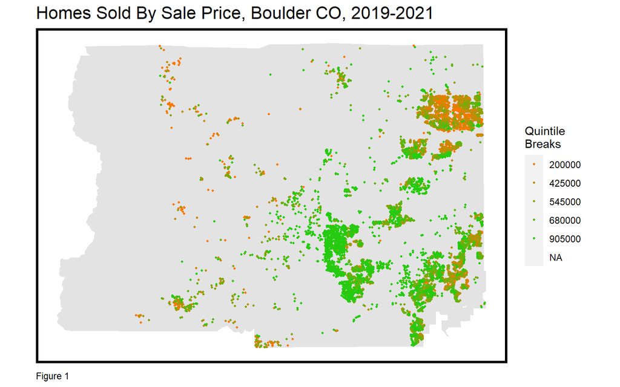

```r
options(scipen = 9999)

#Home Price

ggplot() +
  geom_sf(data = Boulder.Boundary, fill = "grey89", color = "grey89") +
  geom_sf(data = BoulderHousingData, aes(colour = q5(price)),
          show.legend = "point", size = .75) +
  scale_colour_manual(values = palette5,
                   labels=qBr(BoulderHousingData,"price"),
                   name="Quintile\nBreaks",
                   na.value = NA) +
  labs(title="Homes Sold By Sale Price, Boulder CO, 2019-2021",
      caption="Figure 1") +
  mapTheme()
```

## Internal Variables Map

The following are maps of internal housing characteristics that were included in the modeling process.

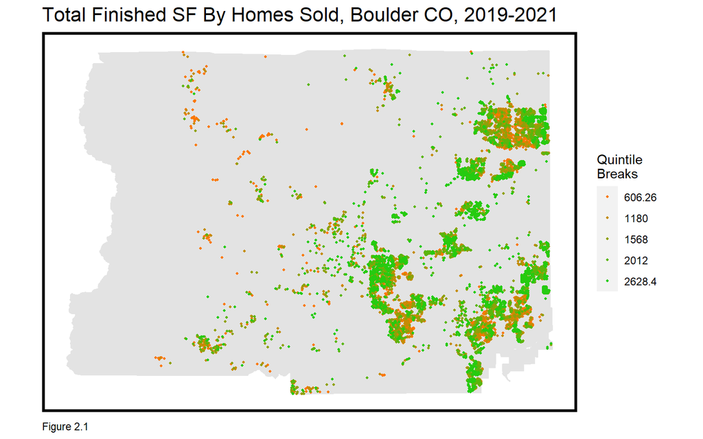

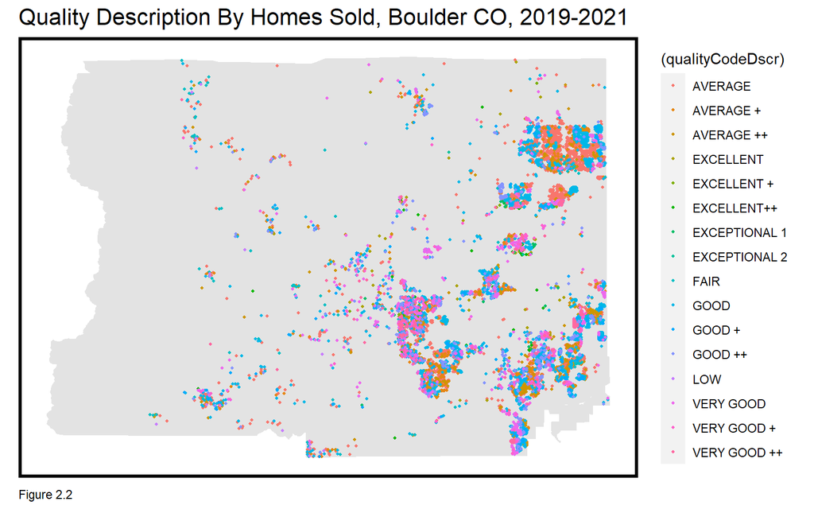

```r
options(scipen = 9999)

#Internal Variables
ggplot() +
  geom_sf(data = Boulder.Boundary, fill = "grey89", color = "grey89") +
  geom_sf(data = BoulderHousingData, aes(colour = q5(TotalFinishedSF)),
          show.legend = "point", size = .75) +
  scale_colour_manual(values = palette5,
                   labels=qBr(BoulderHousingData,"TotalFinishedSF"),
                   name="Quintile\nBreaks") +
  labs(title="Total Finished SF By Homes Sold, Boulder CO, 2019-2021",
       caption="Figure 2.1") +
  mapTheme()

ggplot() +
  geom_sf(data = Boulder.Boundary, fill = "grey89", color = "grey89") +
  geom_sf(data = BoulderHousingData, aes(colour = (qualityCodeDscr)),
          show.legend = "point", size = .75) +
  labs(title="Quality Description By Homes Sold, Boulder CO, 2019-2021",
       caption="Figure 2.2") +
  mapTheme()
```

## Amenities/Services Maps

Below are a series of maps that begin to speak to the relationship between sold home prices and amenities/services across the county. Some of these maps may show descriptive relationships, like how there are a lot of trail heads by expensive homes, but we will explore more of this significance later on.

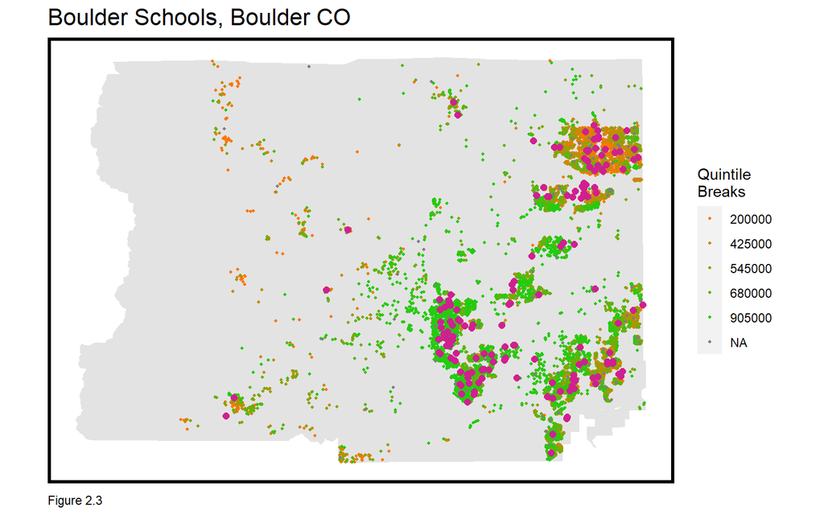

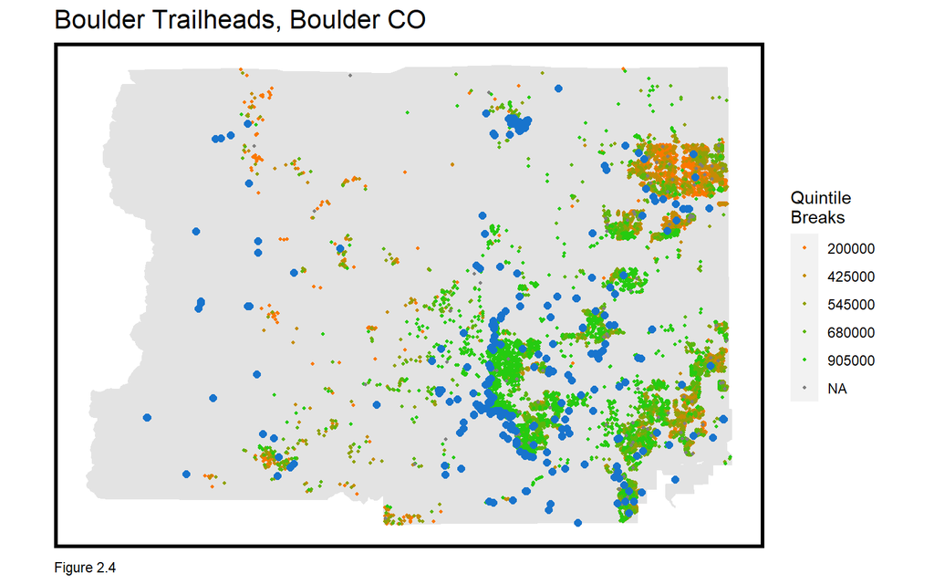

```r
BoulderSchools1 <- st_intersection(Boulder.Boundary, BoulderSchools)

BoulderTrailHeads1 <- st_intersection(Boulder.Boundary, BoulderTrailHeads)

ggplot() +
  geom_sf(data = Boulder.Boundary, fill = "grey89", color = "grey89") +
  geom_sf(data = BoulderHousingData, aes(colour = q5(price)),
          show.legend = "point", size = .75) +
  scale_colour_manual(values = palette5,
                   labels=qBr(BoulderHousingData,"price"),
                   name="Quintile\nBreaks") +
  geom_sf(data = BoulderSchools1, color = "violetred", size = 2) +
  labs(title="Boulder Schools, Boulder CO",
      caption="Figure 2.3") +
  mapTheme()

ggplot() +
  geom_sf(data = Boulder.Boundary, fill = "grey89", color = "grey89") +
  geom_sf(data = BoulderHousingData, aes(colour = q5(price)),
          show.legend = "point", size = .75) +
  scale_colour_manual(values = palette5,
                   labels=qBr(BoulderHousingData,"price"),
                   name="Quintile\nBreaks") +
  geom_sf(data = BoulderTrailHeads1, color = "dodgerblue3", size = 2) +
  labs(title="Boulder Trailheads, Boulder CO",
       caption="Figure 2.4") +
  mapTheme()
```

## Spatial Variables Maps

Lastly, there are maps on spatial variables and home prices.

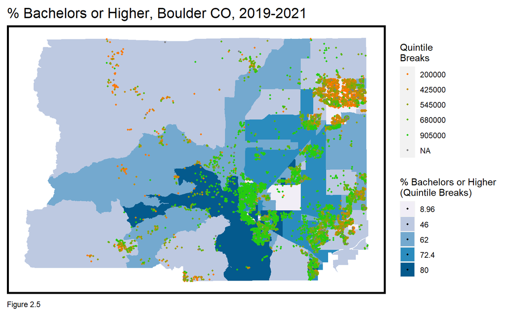

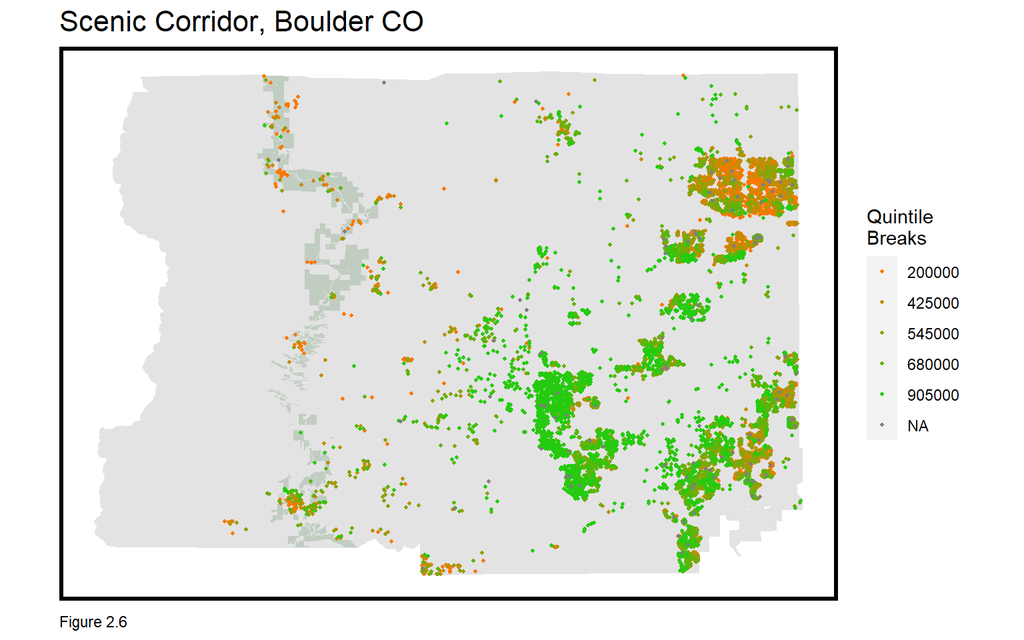

```r
ggplot() +
  geom_sf(data = BoulderCensusData, aes(fill = q5(PerBDorHig)), color = "transparent") +
    scale_fill_brewer(palette = "PuBu",
                      labels = qBr(BoulderCensusData, "PerBDorHig"),
                      name = "% Bachelors or Higher\n(Quintile Breaks)") +
  geom_sf(data = BoulderHousingData, aes(colour = q5(price)),
          show.legend = "point", size = .75) +
  scale_colour_manual(values = palette5,
                   labels=qBr(BoulderHousingData,"price"),
                   name="Quintile\nBreaks") +
  labs(title="% Bachelors or Higher, Boulder CO, 2019-2021",
      caption="Figure 2.5") +
  mapTheme()


ggplot() +
  geom_sf(data = Boulder.Boundary, fill = "grey89", color = "grey89") +
  geom_sf(data = BoulderScenicCorridor, fill = "honeydew3",  color = "transparent") +
  geom_sf(data = BoulderHousingData, fill = "grey50", color = "grey50",
          show.legend = "point", size = .75) +
  geom_sf(data = BoulderHousingData, aes(colour = q5(price)),
          show.legend = "point", size = .75) +
  scale_colour_manual(values = palette5,
                   labels=qBr(BoulderHousingData,"price"),
                   name="Quintile\nBreaks") +
  labs(title="Scenic Corridor, Boulder CO",
       caption="Figure 2.6") +
  mapTheme()
```

## Interesting Variable Maps

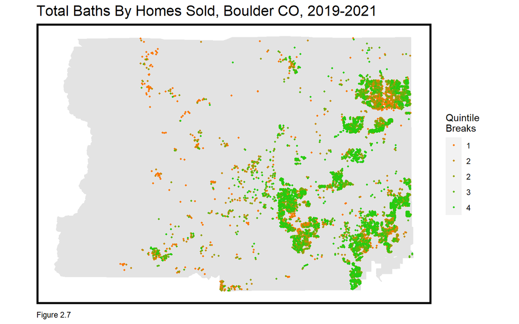

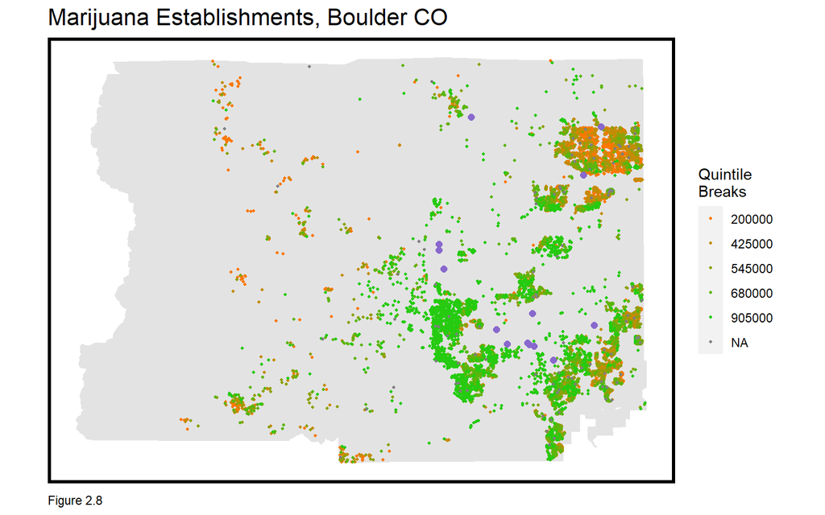

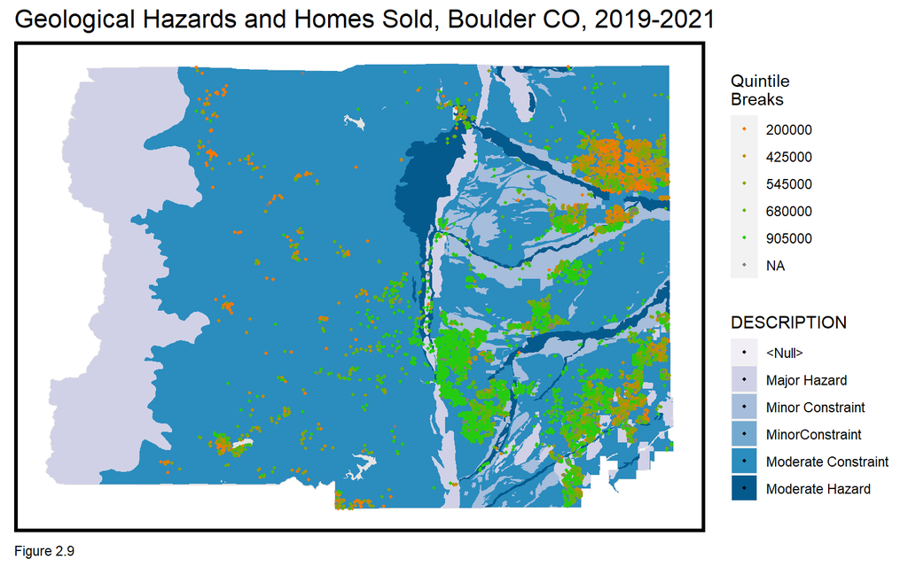

```r
ggplot() +
  geom_sf(data = Boulder.Boundary, fill = "grey89", color = "grey89") +
  geom_sf(data = BoulderHousingData, aes(colour = q5(totalbaths)),
          show.legend = "point", size = .75) +
  scale_colour_manual(values = palette5,
                   labels=qBr(BoulderHousingData,"totalbaths"),
                   name="Quintile\nBreaks") +
  labs(title="Total Baths By Homes Sold, Boulder CO, 2019-2021",
      caption="Figure 2.7") +
  mapTheme()


ggplot() +
  geom_sf(data = Boulder.Boundary, fill = "grey89", color = "grey89") +
  geom_sf(data = BoulderHousingData, aes(colour = q5(price)),
          show.legend = "point", size = .75) +
  scale_colour_manual(values = palette5,
                   labels=qBr(BoulderHousingData,"price"),
                   name="Quintile\nBreaks") +
  geom_sf(data = BoulderMarijuanaEstablishments, color = "mediumpurple3", size = 2) +
  labs(title="Marijuana Establishments, Boulder CO",
       caption="Figure 2.8") +
  mapTheme()

ggplot() +
  geom_sf(data = Boulder.Boundary, fill = "grey89", color = "grey89") +
  geom_sf(data = BoulderGeologicalHazards, aes(fill = DESCRIPTION), color = "transparent") +
  scale_fill_brewer(palette = "PuBu") +
  geom_sf(data = BoulderHousingData, aes(colour = q5(price)),
          show.legend = "point", size = .75) +
  scale_colour_manual(values = palette5,
                   labels=qBr(BoulderHousingData,"price"),
                   name="Quintile\nBreaks") +
  labs(title="Geological Hazards and Homes Sold, Boulder CO, 2019-2021",
       caption="Figure 2.9") +
  mapTheme()
```

## Summary Stats

```r
## Polished training set table
#--- Internal

ss_boulderInternal <- BoulderHousingData

ss_boulderInternal <- st_drop_geometry(ss_boulderInternal)

ss_boulderInternal <- ss_boulderInternal %>%
  dplyr::select("pricesqft", "totalbaths", "builtYear", "bsmtSF", "carStorageSF", "nbrBedRoom", "nbrRoomsNobath", "mainfloorSF", "TotalFinishedSF")

stargazer(as.data.frame(ss_boulderInternal), type="html", digits=1, title = "Descriptive Statistics for Boulder Homes Internal Variables (Figure 3.1)", out = "Training_BoulderInternal.txt")
```

**Descriptive Statistics for Boulder Homes Internal Variables (Figure 3.1)**

| Statistic | N | Mean | St. Dev. | Min | Pctl(25) | Pctl(75) | Max |
| --- | --- | --- | --- | --- | --- | --- | --- |
| pricesqft | 11,264 | 1,085.4 | 29,927.0 | 0.0 | 261.3 | 473.6 | 1,520,000.0 |
| totalbaths | 11,364 | 2.7 | 1.0 | 0 | 2 | 3.5 | 12 |
| builtYear | 11,364 | 1,987.2 | 26.8 | 1,860 | 1,972 | 2,006 | 2,021 |
| bsmtSF | 11,364 | 743.7 | 627.4 | 0 | 133.8 | 1,125 | 4,534 |
| carStorageSF | 11,364 | 471.9 | 235.9 | 0 | 380 | 600 | 3,040 |
| nbrBedRoom | 11,364 | 3.4 | 1.1 | 0 | 3 | 4 | 24 |
| nbrRoomsNobath | 11,364 | 7.4 | 2.1 | 0 | 6 | 9 | 28 |
| mainfloorSF | 11,364 | 1,313.5 | 607.2 | 0 | 923 | 1,619 | 7,795 |
| TotalFinishedSF | 11,364 | 1,955.4 | 892.6 | 0 | 1,276 | 2,443.2 | 10,188 |

```r
#--- Amenities/Services
ss_boulderAS <- BoulderHousingData

ss_boulderAS <- st_drop_geometry(ss_boulderAS)

ss_boulderAS <- ss_boulderAS %>%
  dplyr::select("libraries_nn1", "trailheads_nn1", "ME_nn1","public_nn1","private_nn1")

stargazer(as.data.frame(ss_boulderAS), type="html", digits=1, title="Descriptive Statistics for Boulder Homes Amenities and Services Variables (Figure 3.2)", out = "Training_BoulderExternal.txt")
```

**Descriptive Statistics for Boulder Homes Amenities and Services Variables (Figure 3.2)**

| Statistic | N | Mean | St. Dev. | Min | Pctl(25) | Pctl(75) | Max |
| --- | --- | --- | --- | --- | --- | --- | --- |
| libraries_nn1 | 11,364 | 10,673.2 | 7,832.2 | 168.0 | 5,111.2 | 13,615.9 | 69,429.6 |
| trailheads_nn1 | 11,364 | 3,909.8 | 2,749.0 | 72.2 | 2,013.9 | 5,215.6 | 31,687.6 |
| ME_nn1 | 11,364 | 14,213.8 | 12,012.0 | 694.0 | 7,970.4 | 15,917.6 | 95,516.0 |
| public_nn1 | 11,364 | 4,163.6 | 5,944.6 | 83.2 | 1,651.8 | 4,252.0 | 68,222.0 |
| private_nn1 | 11,364 | 7,315.3 | 12,480.0 | 55.3 | 2,056.6 | 6,605.3 | 103,817.3 |

```r
#--- Amenities/Services
ss_boulderSpatial <- BoulderHousingData

ss_boulderSpatial <- st_drop_geometry(ss_boulderSpatial)

ss_boulderSpatial <- ss_boulderSpatial %>%
  dplyr::select("PerBDorHig","PerWhitePo","MedHHInc")

stargazer(as.data.frame(ss_boulderSpatial), type="html", digits=1, title="Descriptive Statistics for Boulder Homes Spatial Structure Variables (Figure 3.3)", out = "Training_BoulderExternal.txt")
```

**Descriptive Statistics for Boulder Homes Spatial Structure Variables (Figure 3.3)**

| Statistic | N | Mean | St. Dev. | Min | Pctl(25) | Pctl(75) | Max |
| --- | --- | --- | --- | --- | --- | --- | --- |
| PerBDorHig | 11,364 | 63.4 | 16.4 | 0.0 | 53.3 | 73.9 | 94.8 |
| PerWhitePo | 11,364 | 89.9 | 5.4 | 51 | 87.0 | 93.4 | 100 |
| MedHHInc | 11,364 | 102,764.3 | 34,941.3 | 0 | 81,518 | 123,750 | 241,161 |

# Splitting Data for Regressions

```r
## Setting toPrecict==0
Training_Boulder <- filter(BoulderHousingData, toPredict == 0) #removed 100
```

# Exploratory Data Analysis: Correlations

## Exploratory Data Analysis: Scatterplots + Category Variables

The next chunk of code begins to explore the relationships between the variables and home prices. Below are scatterplots, descriptive statistics, and a barplot. For example, the last chart is a barplot of quality by house price, indicating that the higher the quality of the house, the more expensive the house sells for. These help inform which variables we pick for the model later on.

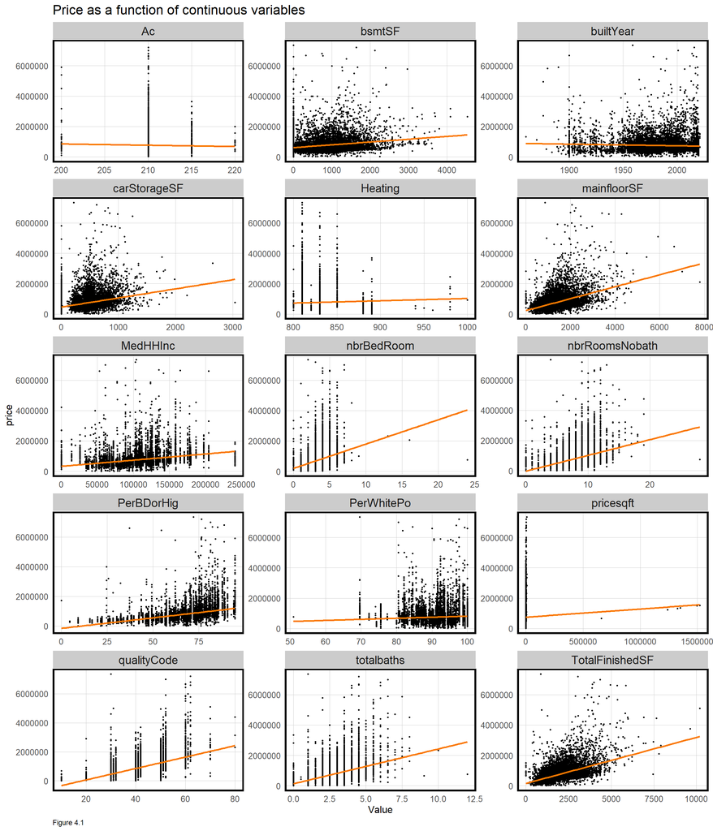

```r
options(scipen = 9999) #turns off scientific notation and how many points

Training_BoulderPlot <- ## IMPORTANT
  Training_Boulder %>%
  filter(price < 10000000)

## Scatterplot
st_drop_geometry(Training_BoulderPlot) %>%
  dplyr::select(price, pricesqft, totalbaths, qualityCode, builtYear, bsmtSF, carStorageSF,nbrBedRoom,
                nbrRoomsNobath, mainfloorSF, TotalFinishedSF, Ac, Heating, PerBDorHig, PerWhitePo,
                MedHHInc, ) %>%
  filter(price < 10000000) %>%
  gather(Variable, Value, -price) %>%
   ggplot(aes(Value, price)) +
     geom_point(size = .5) + geom_smooth(method = "lm", se=F, colour = "#FA7800") +
     facet_wrap(~Variable, ncol = 3, scales = "free") +
     labs(title = "Price as a function of continuous variables",
          caption="Figure 4.1") +
     plotTheme()
## `geom_smooth()` using formula 'y ~ x'
```

## Exploratory Data Analysis: Categorical Variable

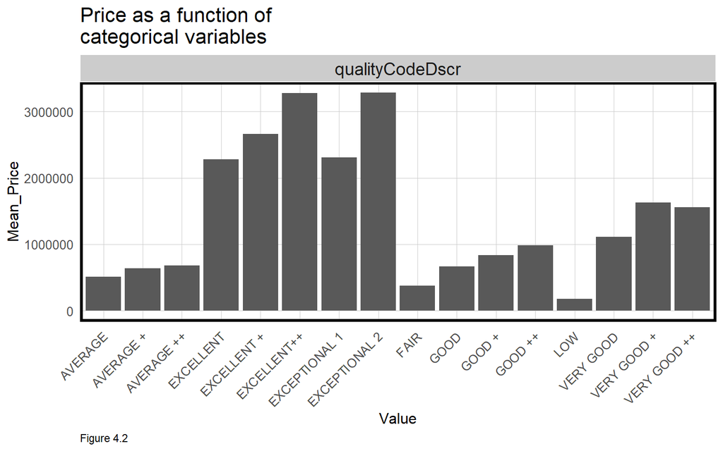

```r
# separate because above has specific figure height
## Barplot
plot <-
  st_drop_geometry(Training_Boulder) %>%
  dplyr::select(price, qualityCodeDscr) %>%
  gather(Variable, Value, -price) %>%
   ggplot(aes(Value, price)) +
     geom_bar(position = "dodge", stat = "summary", fun.y = "mean") +
     facet_wrap(~Variable, ncol = 1, scales = "free") +
     labs(title = "Price as a function of\ncategorical variables", y = "Mean_Price",
          caption="Figure 4.2") +
     plotTheme() + theme(axis.text.x = element_text(angle = 45, hjust = 1))

plot
## No summary function supplied, defaulting to `mean_se()`
```

## Exploratory Data Analysis: Correlation Matrix

Below is another visualization explaining correlation. For this visualization, we are mostly focused on price and how it relates to the variables that might be included in the model. We notice that there are some variables with strong positive and negative correlations, which begins our selection process.

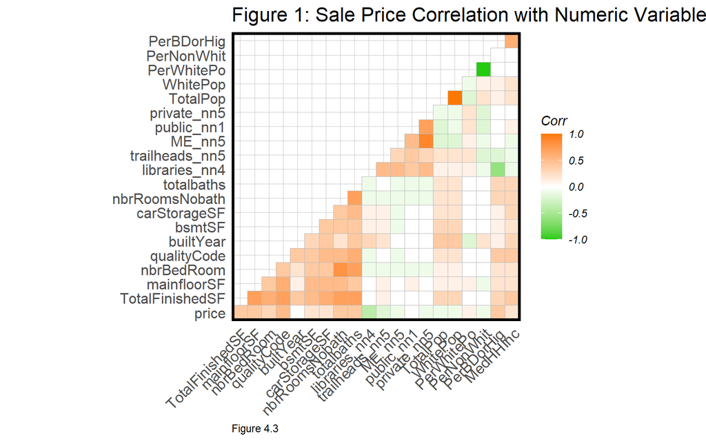

```r
## Correlation Matrix

numericVars <- st_drop_geometry(Training_Boulder) %>%
  dplyr::select(price, TotalFinishedSF, mainfloorSF, nbrBedRoom, qualityCode, builtYear, bsmtSF, carStorageSF, nbrRoomsNobath, totalbaths, libraries_nn4, trailheads_nn5, ME_nn5, public_nn1, private_nn5, TotalPop, WhitePop, PerWhitePo, PerNonWhit, PerBDorHig, MedHHInc) %>%
  select(where(is.numeric)) %>%
  na.omit()

ggcorrplot(
  round(cor(numericVars), 1),
  p.mat = cor_pmat(numericVars),
  colors = c("#25CB10", "white", "#FA7800"),
  type="lower",
  insig = "blank") +
    labs(title = "Figure 1: Sale Price Correlation with Numeric Variables",
         caption="Figure 4.3") +
  plotTheme()
```

```r
## Pearson's Test
cor.test(Training_Boulder$price, Training_Boulder$libraries_nn1, method = "pearson")
```

```
##
##  Pearson's product-moment correlation
##
## data:  Training_Boulder$price and Training_Boulder$libraries_nn1
## t = -2.7543, df = 11262, p-value = 0.005892
## alternative hypothesis: true correlation is not equal to 0
## 95 percent confidence interval:
##  -0.044391355 -0.007481029
## sample estimates:
##         cor
## -0.02594503
```

## Interesting Scatterplots by Sale Price

Below are interesting scatterplots pulled from prior code. All of these scatterplots depict either rising or falling home prices in relation to distance to/from or concentration of certain populations.

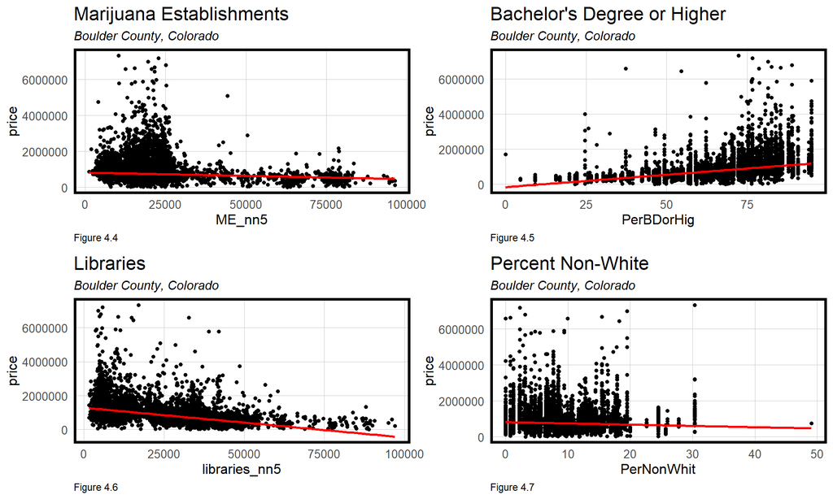

```r
## Marijuana Establishments
ME <- ggplot(data = Training_BoulderPlot, aes(x = ME_nn5, y = price)) +
  geom_point(size=2, shape=20)  +
  labs(title = "Marijuana Establishments", subtitle = "Boulder County, Colorado", caption="Figure 4.4") +
  geom_smooth(method = "lm", se=F, colour = "red") +
  plotTheme()

## Bachelor's Degree or Higher
BD <- ggplot(data = Training_BoulderPlot, aes(x = PerBDorHig, y = price)) +
  geom_point(size=2, shape=20)  +
  labs(title = "Bachelor's Degree or Higher", subtitle = "Boulder County, Colorado", caption="Figure 4.5") +
  geom_smooth(method = "lm", se=F, colour = "red") +
  plotTheme()

## Libraries
LB <- ggplot(data = Training_BoulderPlot, aes(x = libraries_nn5, y = price)) +
  geom_point(size=2, shape=20)  +
  labs(title = "Libraries", subtitle = "Boulder County, Colorado", caption="Figure 4.6") +
  geom_smooth(method = "lm", se=F, colour = "red") +
  plotTheme()

## Percent Non-White
NW <- ggplot(data = Training_BoulderPlot, aes(x = PerNonWhit, y = price)) +
  geom_point(size=2, shape=20)  +
  labs(title = "Percent Non-White", subtitle = "Boulder County, Colorado", caption="Figure 4.7") +
  geom_smooth(method = "lm", se=F, colour = "red") +
  plotTheme()

grid.arrange(ME, BD, LB, NW, nrow = 2)
## `geom_smooth()` using formula 'y ~ x'
## `geom_smooth()` using formula 'y ~ x'
## `geom_smooth()` using formula 'y ~ x'
## `geom_smooth()` using formula 'y ~ x'
```

# Regression Model

```r
# First Regression Test
first.regression <- lm(price ~ ., data = st_drop_geometry(Training_Boulder) %>%
                                 dplyr::select(price, TotalFinishedSF, mainfloorSF, nbrBedRoom, qualityCode, bsmtSF, carStorageSF, nbrRoomsNobath, totalbaths, TotalPop, PerBDorHig, MedHHInc, libraries_nn2, libraries_nn3, libraries_nn4, libraries_nn5, trailheads_nn2, trailheads_nn3, trailheads_nn4, trailheads_nn5, ME_nn1, ME_nn5, private_nn1, private_nn2, private_nn5))
summary(first.regression)
```

```
##
## Call:
## lm(formula = price ~ ., data = st_drop_geometry(Training_Boulder) %>%
##     dplyr::select(price, TotalFinishedSF, mainfloorSF, nbrBedRoom,
##         qualityCode, bsmtSF, carStorageSF, nbrRoomsNobath, totalbaths,
##         TotalPop, PerBDorHig, MedHHInc, libraries_nn2, libraries_nn3,
##         libraries_nn4, libraries_nn5, trailheads_nn2, trailheads_nn3,
##         trailheads_nn4, trailheads_nn5, ME_nn1, ME_nn5, private_nn1,
##         private_nn2, private_nn5))
##
## Residuals:
##      Min       1Q   Median       3Q      Max
## -1709885  -171918   -22981    99409 30738441
##
## Coefficients:
##                     Estimate   Std. Error t value             Pr(>|t|)
## (Intercept)     196345.29270  48627.68990   4.038         0.0000543301 ***
## TotalFinishedSF    119.17307     10.35982  11.503 < 0.0000000000000002 ***
## mainfloorSF        133.34692     11.26947  11.833 < 0.0000000000000002 ***
## nbrBedRoom      -19529.05542   6910.45879  -2.826              0.00472 **
## qualityCode      21682.89502    891.46813  24.323 < 0.0000000000000002 ***
## bsmtSF             -17.02235      9.11023  -1.868              0.06172 .
## carStorageSF       -19.32101     24.38072  -0.792              0.42810
## nbrRoomsNobath    1947.35529   3713.71236   0.524              0.60003
## totalbaths       42322.77776   7700.09970   5.496         0.0000000396 ***
## TotalPop           -67.89010      4.09364 -16.584 < 0.0000000000000002 ***
## PerBDorHig       -1071.72288    520.86689  -2.058              0.03965 *
## MedHHInc            -0.05499      0.16915  -0.325              0.74510
## libraries_nn2       22.43093      1.99527  11.242 < 0.0000000000000002 ***
## libraries_nn3      -34.72349      7.52147  -4.617         0.0000039444 ***
## libraries_nn4        1.31300     18.88616   0.070              0.94458
## libraries_nn5       -4.78124     11.81557  -0.405              0.68574
## trailheads_nn2     -31.92391     11.20344  -2.849              0.00439 **
## trailheads_nn3      69.55257     30.43155   2.286              0.02230 *
## trailheads_nn4      16.45420     36.95272   0.445              0.65613
## trailheads_nn5     -55.38995     19.87625  -2.787              0.00533 **
## ME_nn1              -0.27206      1.33804  -0.203              0.83889
## ME_nn5               7.50064      1.46969   5.104         0.0000003388 ***
## private_nn1        -27.39653      6.90927  -3.965         0.0000737937 ***
## private_nn2         61.28900     10.65348   5.753         0.0000000090 ***
## private_nn5        -34.67539      6.19878  -5.594         0.0000000227 ***
## ---
## Signif. codes:  0 '***' 0.001 '**' 0.01 '*' 0.05 '.' 0.1 ' ' 1
##
## Residual standard error: 458900 on 11239 degrees of freedom
## Multiple R-squared:  0.4465, Adjusted R-squared:  0.4453
## F-statistic: 377.8 on 24 and 11239 DF,  p-value: < 0.00000000000000022
```

```r
## Regression for Training with CATEGORICAL VARIABLES
regression <- lm(price ~ ., data = st_drop_geometry(Training_Boulder) %>%
                                 dplyr::select(price, bsmtSF, carStorageSF, TotalFinishedSF, nbrRoomsNobath, totalbaths, PerBDorHig, libraries_nn4, trailheads_nn5, ME_nn5,private_nn5, DESCRIPTION, bsmtType, carStorageType,qualityCodeDscr, Geo_QName, BoulderHousingData.Buffer.LR, SC, FZ, WF))
```

## Regression Model Stats

```r
#---Polished LM table of training dataset
stargazer(regression, type="html", digits=1, title="Linear Model of Training Dataset (Figure 5)", out = "Training LM.txt")
```

**Linear Model of Training Dataset (Figure 5)**

|  | *Dependent variable:* |
| --- | --- |
|  | price |
| bsmtSF | 10.3 |
|  | (10.1) |
| carStorageSF | 33.3 |
|  | (28.6) |
| TotalFinishedSF | 154.1*** |
|  | (9.6) |
| nbrRoomsNobath | -1,397.7 |
|  | (3,086.9) |
| totalbaths | 16,143.8** |
|  | (7,076.5) |
| PerBDorHig | 42,510.5*** |
|  | (5,987.3) |
| libraries_nn4 | -3.6 |
|  | (3.3) |
| trailheads_nn5 | -1.3 |
|  | (2.9) |
| ME_nn5 | 3.7 |
|  | (2.5) |
| private_nn5 | -2.0 |
|  | (3.0) |
| DESCRIPTIONMinor Constraint | 27,095.4 |
|  | (36,251.2) |
| DESCRIPTIONModerate Constraint | 9,949.2 |
|  | (31,116.4) |
| DESCRIPTIONModerate Hazard | 1,414.6 |
|  | (50,054.4) |
| bsmtTypeBGF | 55,866.2** |
|  | (27,680.4) |
| bsmtTypeBGU | 23,925.8 |

[output cut: 571 more lines]

## Partition and Predictions

At this point, our data was partitioned in a 75/25 training and test split. First we ran a regression on a training set, which contained 75% of the data. Then using this regression, we carry it over and test its generalizability on the test set.

```r
set.seed(999) #makes sure data is split same way every time

## Partition
inTrain <- createDataPartition(
              y = paste(Training_Boulder$DESCRIPTION, Training_Boulder$Geo_QName),
              p = .75, list = FALSE)

## Creating the training and test set
TrainingBoulder <- BoulderHousingData[inTrain,]
TestBoulder <- BoulderHousingData[-inTrain,]

## Regression on training set post partition.

regression_trainingboulder <- lm(price ~ ., data = st_drop_geometry(TrainingBoulder) %>%
                                 dplyr::select(price, bsmtSF, carStorageSF, TotalFinishedSF, nbrRoomsNobath, totalbaths, PerBDorHig, libraries_nn4, trailheads_nn5, ME_nn5,private_nn5, DESCRIPTION, bsmtType, carStorageType,qualityCodeDscr, Geo_QName, BoulderHousingData.Buffer.LR, SC, FZ, WF))
summary(regression_trainingboulder)
```

```
##
## Call:
## lm(formula = price ~ ., data = st_drop_geometry(TrainingBoulder) %>%
##     dplyr::select(price, bsmtSF, carStorageSF, TotalFinishedSF,
##         nbrRoomsNobath, totalbaths, PerBDorHig, libraries_nn4,
##         trailheads_nn5, ME_nn5, private_nn5, DESCRIPTION, bsmtType,
##         carStorageType, qualityCodeDscr, Geo_QName, BoulderHousingData.Buffer.LR,
##         SC, FZ, WF))
##
## Residuals:
##      Min       1Q   Median       3Q      Max
## -2262503   -86986    -2820    75166  6300855
##
## Coefficients: (1 not defined because of singularities)
##                                                                           Estimate
## (Intercept)                                                           -1830781.180
## bsmtSF                                                                       4.008
## carStorageSF                                                                20.938
## TotalFinishedSF                                                            160.146
## nbrRoomsNobath                                                            1820.257
## totalbaths                                                               13151.674
## PerBDorHig                                                               39831.237
## libraries_nn4                                                               -1.714
## trailheads_nn5                                                              -1.828
## ME_nn5                                                                       3.544
## private_nn5                                                                 -3.064
## DESCRIPTIONMinor Constraint                                              30858.273
## DESCRIPTIONModerate Constraint                                           -2221.546
## DESCRIPTIONModerate Hazard                                               16416.682
## bsmtTypeBGF                                                              48020.697
## bsmtTypeBGU                                                              14841.480
## bsmtTypeBSF                                                              41704.479
## bsmtTypeBSU                                                               7111.204
## bsmtTypeBWF                                                              69043.475
## bsmtTypeBWU                                                              20100.794
## bsmtTypeLGF                                                              73803.351
## bsmtTypeLGU                                                             -40591.945
## bsmtTypeLWF                                                             115887.052
## bsmtTypeLWU                                                             171249.167
## carStorageTypeGRA                                                        32086.518
```

[output cut: 1176 more lines]

```
## Geo_QNameBlock Group 5, Census Tract 137.02, Boulder County, Colorado
## Geo_QNameBlock Group 5, Census Tract 608, Boulder County, Colorado    ***
## Geo_QNameBlock Group 6, Census Tract 137.02, Boulder County, Colorado **
## Geo_QNameBlock Group 7, Census Tract 137.02, Boulder County, Colorado
## BoulderHousingData.Buffer.LR
## SC
## FZ
## WF                                                                    ***
## ---
## Signif. codes:  0 '***' 0.001 '**' 0.01 '*' 0.05 '.' 0.1 ' ' 1
##
## Residual standard error: 293600 on 8304 degrees of freedom
##   (12 observations deleted due to missingness)
## Multiple R-squared:  0.7199, Adjusted R-squared:  0.7118
## F-statistic: 89.29 on 239 and 8304 DF,  p-value: < 0.00000000000000022
```

```r
## Using the regression from training, we test it on the TestBoulder dataset.
TestBoulder <-
  TestBoulder %>%
  mutate(Price.Predict = predict(regression_trainingboulder, TestBoulder),
         Price.Error = Price.Predict - price,
         Price.AbsError = abs(Price.Predict - price),
         Price.APE = (abs(Price.Predict - price)) / Price.Predict)

## CHALLENGE
#Predictions <- filter(TestBoulder, toPredict == 1)

#PredictionsExport <- subset(Predictions, select = c("MUSA_ID", "Price.Predict")) %>% st_drop_geometry()

#write.csv(PredictionsExport, "TheDevelopers.csv")
```

# Evaluation Methods

In carrying out the design of our model, we use a variety of methods providing results that will assist us in determining our models power.

- After the creation of our regression model, we gather the mean absolute error (MAE) and mean absolute percentage error (MAPE) for prices to determine accuracy.
- Use the K-Fold cross validation method. This method determines the generalizability of our model by creating 100 fold sets and does 100 regressions leaving one part of the data out of the analysis each time.
- We then use the Moran’s I tool to look at spatial autocorrelation, or the clustering effect on home prices. This allows us to see if any spatial features influenced the errors in our model.

# Accuracy, K-Fold, and Cross Validation

As mentioned above, these are methods to evaluate our model. Our mean MAE (price absolute error) was 157,583 and our MAPE was 22%.

```r
## Accuracy - Mean Absolute Error
MAE <- data.frame(mean(TestBoulder$Price.AbsError, na.rm = T))
MAPE <- data.frame(mean(TestBoulder$Price.APE, na.rm = T)) #MAPE

reg.MAE.MAPE <-
  cbind(MAE, MAPE) %>%
  kable(caption = "Regression MAE & MAPE (Figure 5.1)") %>%
  kable_styling("striped",full_width = F)

reg.MAE.MAPE
```

Regression MAE & MAPE (Figure 5.1)

| mean.TestBoulder.Price.AbsError..na.rm…T. | mean.TestBoulder.Price.APE..na.rm…T. |
| --- | --- |
| 157583.2 | 0.2233854 |

```r
TestBoulderFilter <-
  TestBoulder %>%
  filter(price < 10000000)


## K-Fold: Generalizability Cross-Validation
fitControl <- trainControl(method = "cv", number = 100)
set.seed(825)

reg.cv <-
  train(price ~ ., data = st_drop_geometry(TrainingBoulder) %>%
                                dplyr::select(price, bsmtSF, carStorageSF, TotalFinishedSF,
                                              nbrRoomsNobath, totalbaths, PerBDorHig, libraries_nn4,
                                              trailheads_nn5, ME_nn5,private_nn5, DESCRIPTION, bsmtType,
                                              carStorageType, qualityCodeDscr, Geo_QName,
                                              BoulderHousingData.Buffer.LR, SC, FZ, WF),
method = "lm", trControl = fitControl, na.action = na.pass)

reg.cv <- reg.cv

#This needs to be work-shopped. It stopped working and I don't know why. The code without an object assigned also outputs.

reg.cv$resample[1:5,]
```

```
##       RMSE  Rsquared      MAE Resample
## 1 293842.3 0.5805526 148811.3  Fold001
## 2 271232.7 0.6764844 158608.3  Fold002
## 3 415772.3 0.6722201 167755.7  Fold003
## 4 254140.4 0.6430009 155712.7  Fold004
## 5 163574.8 0.8810844 111274.0  Fold005
```

```r
mean(reg.cv$resample[,3])
```

```
## [1] 154584.6
```

```r
reg.cv$resample[7,]
```

```
##     RMSE  Rsquared      MAE Resample
## 7 457194 0.6409066 199433.6  Fold007
```

```r
#leave this separate because of the as is results

stargazer(as.data.frame(reg.cv$resample), type="html", digits=1, title="Cross Validation Results (5.2)", out = "CV.txt") #all cv
```

**Cross Validation Results (5.2)**

| Statistic | N | Mean | St. Dev. | Min | Pctl(25) | Pctl(75) | Max |
| --- | --- | --- | --- | --- | --- | --- | --- |
| RMSE | 100 | 290,220.8 | 105,356.4 | 138,974.0 | 211,393.8 | 335,291.3 | 731,686.9 |
| Rsquared | 100 | 0.7 | 0.1 | 0.2 | 0.7 | 0.8 | 0.9 |
| MAE | 100 | 154,584.6 | 27,530.3 | 101,157.6 | 132,582.1 | 172,896.0 | 219,693.0 |

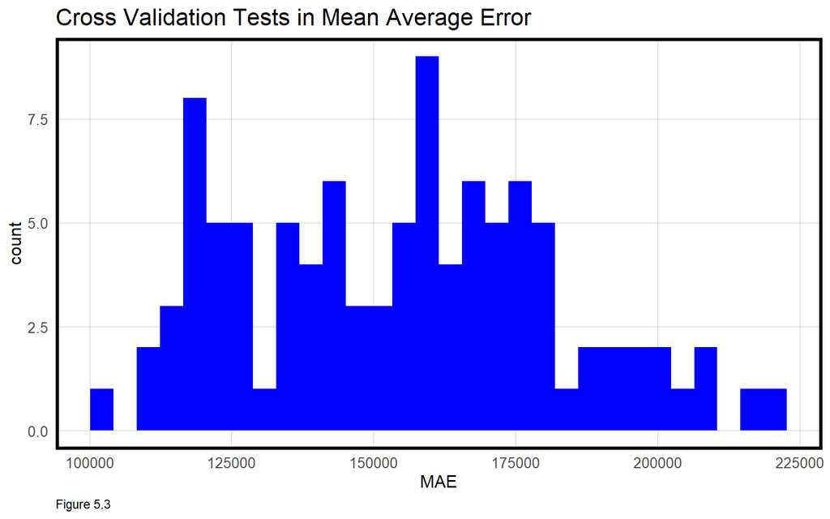

```r
ggplot(reg.cv$resample, aes(x=MAE)) +
  geom_histogram(fill = "blue") +
  labs(title = "Cross Validation Tests in Mean Average Error", caption="Figure 5.3") +
  plotTheme()
## `stat_bin()` using `bins = 30`. Pick better value with `binwidth`.
```